# Kinetochore-microtubule error correction

### Line plots

Here is a plot of median time as a function of replacement rate and conversion rate, for two selected values of the knockoff rate.

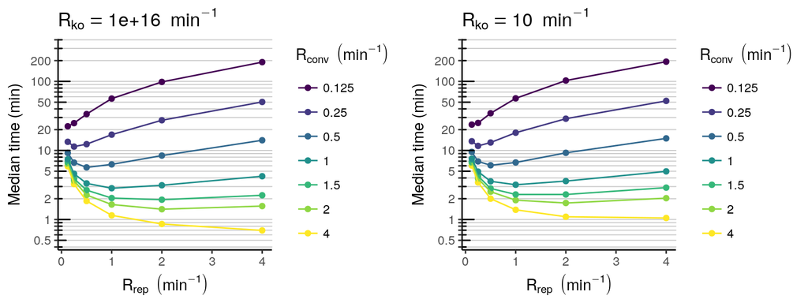

### Heatmaps

Here is the heatmap for knockoff rate fixed at 1e16 (no delay) and 1.

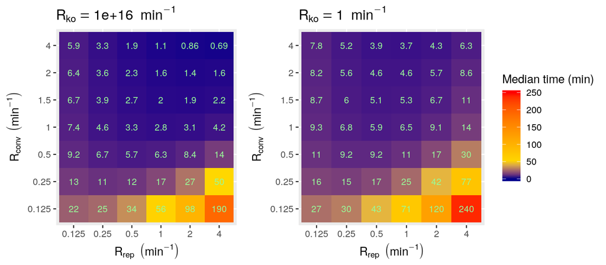

Very quick error correction times are achieved for high conversion rates. The knock-off delay has detrimental effect on these times.

The next heatmap shows conversion rate fixed at our best estimate of ~2 per min.

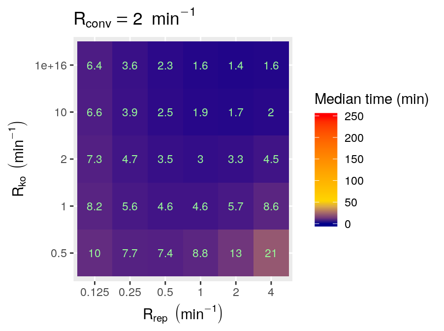

### Distribution plots

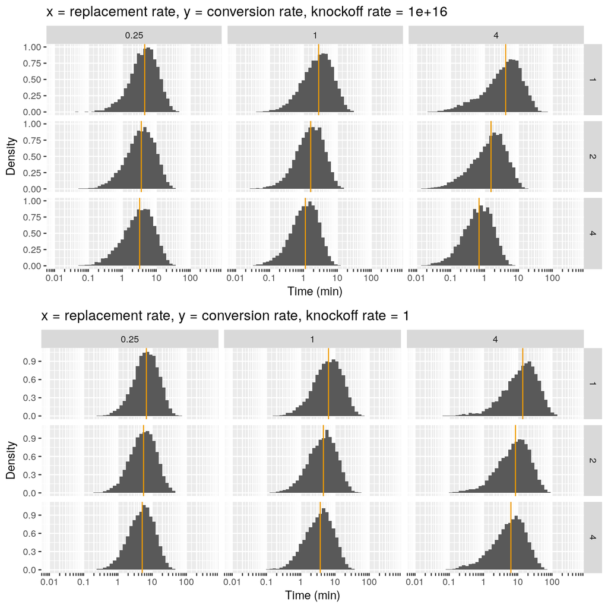

### Examples (instant knock-off)

A few examples of simulation runs for a fast model 2 (that is $R_\mathrm{repl}=2$, $R_\mathrm{conv}=2$ and $R_\mathrm{ko}=1e16$):

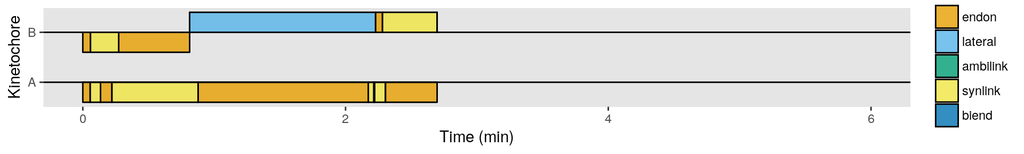

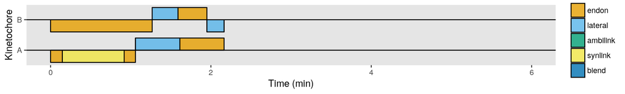

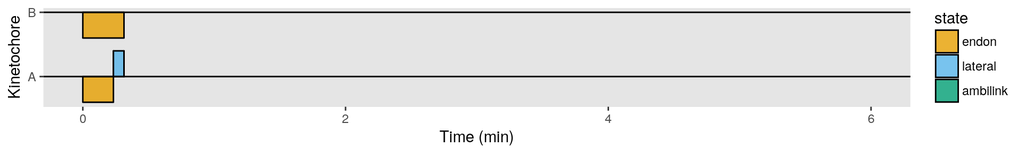

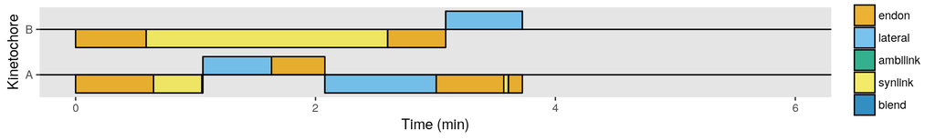

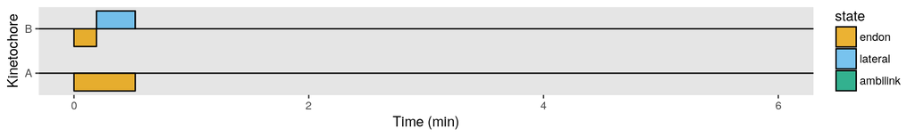

### Examples (knock-off delay)

Here are examples as above, but with $R_\mathrm{ko}=1$:

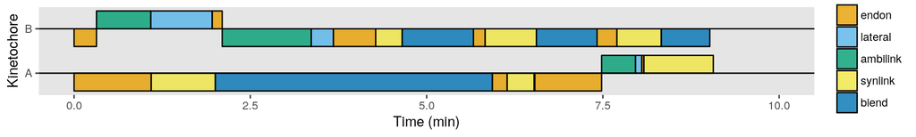

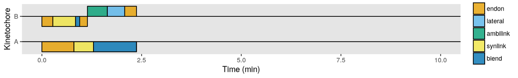

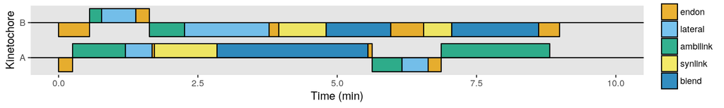

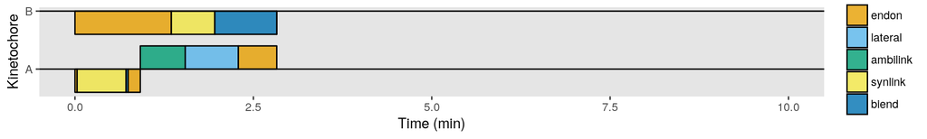

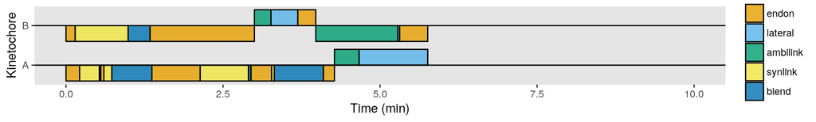

## Detached KTs

In this Section we investigate how long the system spends in configuration where both kinetochores are detached at the same time (model M1 only).

### Detached duration fraction

First, we calculate the fraction of the total time spend as fully detached. Here are plots showing the detached fraction across the range of parameters.

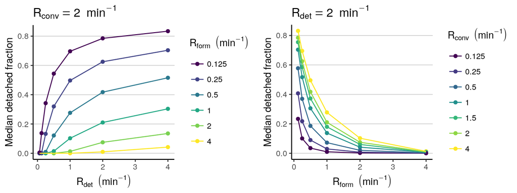

Detached periods are getting long for small formation rate and high detachment rate (as expected).

### Detached time distribution

Now, we turn to individual fully detached periods. We notice that the individual detached times depend almost exclusively on the formation rate. We can clearly see this when plotting median detached time:

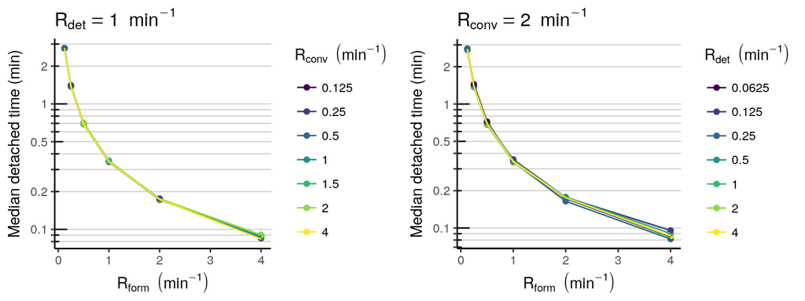

Hence, we can simplify distribution plots. We fix $R_\mathrm{conv} = 2$ and $R_\mathrm{det} = 1~\mathrm{min}^{-1}$ and show the full range of formation rate (the same distribution in linear of logarithmic scale).

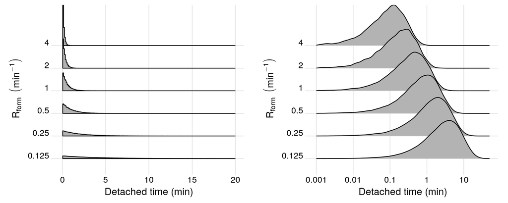

### Diffusion distance scale

Next, we find the diffusion range, defined as $\sigma = \sqrt{6 D t}$, where $D = 0.1~\mu \mathrm{m}^2\mathrm{min}^{-1}$ is the diffusion coefficient and $t$ is the detachment time. We fix $R_\mathrm{conv} = 2$ and $R_\mathrm{det} = 1~\mathrm{min}^{-1}$ and show the full range of formation rate (the same distribution in linear of logarithmic scale).

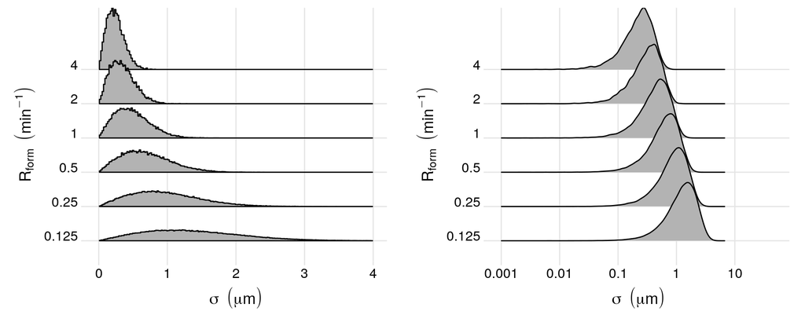

Let us consider $R_\mathrm{form} = 1~\mathrm{min}^{-1}$. For this, the median diffusion range is $\sigma$ = 0.46 $\mu$m. This is the standard deviation of the Gaussian distribution. Hence, about 95% of KTs will not strand farther than about $2\sigma$ = 0.92 $\mu$m.

### Mean diffusion

Here we take the $\sigma$ distribution from the above figure (for each formation rate). Then, for each individual $\sigma$ from the distribution we build the corresponding Gaussian distribution, describing the local diffusion distance. We add up all the distributions to create a “pile-up”. This describes the average distribution of diffusion distances across all observed detachment times. Here is the result. The vertical red lines show the size of the nucleus. Again, we fix $R_\mathrm{conv} = 2$ and $R_\mathrm{det} = 1~\mathrm{min}^{-1}$

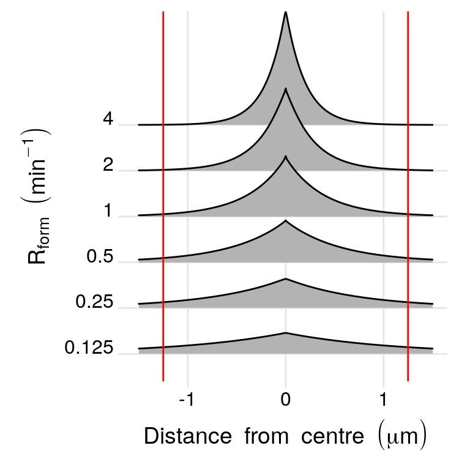

The table below shows the fraction of KTs that diffuse within the nucleus (that is, the area of each distribution within the red lines):

| Form rate | Fraction in nuc |
| --- | --- |
| 4 | 1.00 |
| 2 | 0.99 |
| 1 | 0.96 |
| 0.5 | 0.90 |
| 0.25 | 0.80 |
| 0.125 | 0.69 |

## 16 chromosomes

The model described in this document simulates error correction for one chromosome (sister chromatids). In yeast, we have 16 chromosomes. What is the total time required to correct all chromosomes and establish proper bi-orientation? If error correction for all of them is done in parallel, then the total time is the longest of the individual times. We can model this by randomly sampling 16 timelines from our simulation results and finding the maximum time. NOTE: this is a very conservative approach assuming that *all* chromosomes start in an erroneous configuration.

We select data with the following (default) parameters (units are 1 / minute).

- M1: $R_\mathrm{form} = 1$, $R_\mathrm{conv} = 2$, $R_\mathrm{det} = 1$
- M2: $R_\mathrm{repl} = 1$, $R_\mathrm{conv} = 2$, $R_\mathrm{ko} = 10$

These plots show the distribution of the maximum time across 16 randomly selected samples:

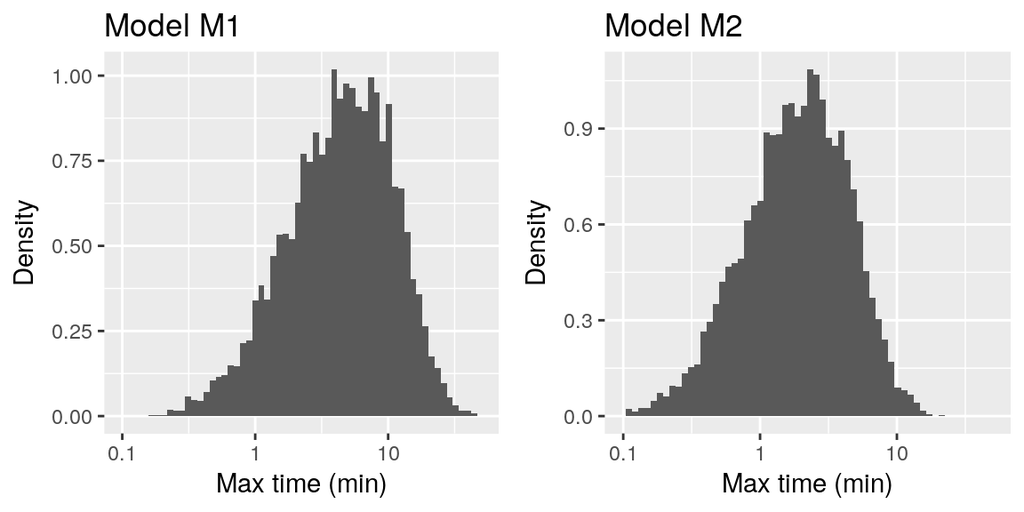